# Case study 1: Distinguishing vertical and horizontal pleiotropy for SNP-protein associations

This RMarkdown document demonstrates how key elements from the [notebook for case study 1 in the EpiGraphDB paper](https://github.com/MRCIEU/epigraphdb/blob/master/paper-case-studies/case-1-pleiotropy.ipynb) can be achieved using the R package. For detailed explanations of the case study please refer to the paper or the [case study notebook](https://github.com/MRCIEU/epigraphdb/blob/master/paper-case-studies/case-1-pleiotropy.ipynb).

## Context

Mendelian randomization (MR), a technique to evaluate the causal role of modifiable exposures on a health outcome using a set of genetic instruments, tacitly assumes that a genetic variant (e.g. SNP) is only related to an outcome of interest through an exposure (i.e. the “exclusion restriction criterion”). Horizontal pleiotropy, where a SNP is associated with multiple phenotypes independently of the exposure of interest, potentially violates this assumption delivering misleading conclusions. In contrast, vertical pleiotropy, where a SNP is associated with multiple phenotypes on the same biological pathway, does not violate this assumption.

Here, we use external evidence on biological pathways and protein-protein interactions to assess the pleiotropic profile for a genetic variant based on the genes (and proteins) with which that variant is associated. In a graph representation, we will show that:

- We have evidence of potential **vertical** pleiotropy when the proteins associated with a variant belong to one connected group,
- In contrast, if the proteins associated with a single variant are isolated from each other, this suggests evidence of **horizontal** pleiotropy.

This case study goes as follows:

- For a list of genes that we wish to assess their pleiotropic profiles (against a variant of interests), we retrieve from EpiGraphDB their mapped protein products.
- Then respectively from the evidence on shared pathway network and protein-protein interaction network, we can extract the proteins groups formed in these networks as connected communities to assess the pleiotropic profiles of the genes.

```r
library("magrittr")
library("dplyr")
library("purrr")
library("glue")
library("igraph")
library("epigraphdb")
```

Here we configure the parameters used in the case study example. In this example we will look at the variant **rs12720356**, a SNP located in chromosome 19 that has been associated with Crohn’s disease and psoriasis.**

```r
SNP <- "rs12720356"

GENELIST <- c("ZGLP1", "FDX1L", "MRPL4", "ICAM5", "TYK2", "GRAP2", "KRI1", "TMED1", "ICAM1")

PPI_N_INTERMEDIATE_PROTEINS <- 1
```

## Mapping genes to proteins

The first step of the analysis is to map each of these genes to their protein product.

```r
get_gene_protein <- function(genelist) {
  endpoint <- "/mappings/gene-to-protein"
  params <- list(
    gene_name_list = genelist %>% I()
  )
  r <- query_epigraphdb(
    route = endpoint,
    params = params,
    mode = "table",
    method = "POST"
  )
  protein_df <- r
  if (nrow(protein_df) > 0) {
    res_df <- protein_df %>%
      select(gene_name = `gene.name`, uniprot_id = `protein.uniprot_id`)
  } else {
    res_df <- tibble() %>% set_names(c("gene_name", "uniprot_id"))
  }

  res_df
}

gene_protein_df <- get_gene_protein(genelist = GENELIST)
gene_protein_df
```

```
#> # A tibble: 9 x 2
#>   gene_name uniprot_id
#>   <chr>     <chr>
#> 1 ZGLP1     P0C6A0
#> 2 FDX1L     Q6P4F2
#> 3 MRPL4     Q9BYD3
#> 4 ICAM5     Q9UMF0
#> 5 TYK2      P29597
#> 6 GRAP2     O75791
#> 7 KRI1      Q8N9T8
#> 8 TMED1     Q13445
#> 9 ICAM1     P05362
```

## Identifying the involvement in the same biological pathways

For each protein we retrieve the pathways they are involved in.

```r
get_protein_pathway <- function(gene_protein_df) {
  endpoint <- "/protein/in-pathway"
  params <- list(
    uniprot_id_list = gene_protein_df %>% pull(`uniprot_id`) %>% I()
  )
  df <- query_epigraphdb(route = endpoint, params = params, mode = "table", method = "POST")

  if (nrow(df) > 0) {
    res_df <- gene_protein_df %>%
      select(`uniprot_id`) %>%
      left_join(df, by = c("uniprot_id"))
  } else {
    res_df <- gene_protein_df %>%
      select(`uniprot_id`) %>%
      mutate(pathway_count = NA_integer_, pathway_reactome_id = NA_character_)
  }
  res_df <- res_df %>%
    mutate(
      pathway_count = ifelse(is.na(pathway_count), 0L, as.integer(pathway_count)),
      pathway_reactome_id = ifelse(is.na(pathway_reactome_id), c(), pathway_reactome_id)
    )

  res_df
}
pathway_df <- get_protein_pathway(gene_protein_df = gene_protein_df)
pathway_df
```

```
#> # A tibble: 9 x 3
#>   uniprot_id pathway_count pathway_reactome_id
#>   <chr>              <int> <list>
#> 1 P0C6A0                 0 <NULL>
#> 2 Q6P4F2                15 <chr [15]>
#> 3 Q9BYD3                 6 <chr [6]>
#> 4 Q9UMF0                 5 <chr [5]>
#> 5 P29597                28 <chr [28]>
#> 6 O75791                15 <chr [15]>
#> 7 Q8N9T8                 0 <NULL>
#> 8 Q13445                 0 <NULL>
#> 9 P05362                11 <chr [11]>
```

Now for each pair of proteins we match the pathways they have in common.

```r
get_shared_pathway <- function(pathway_df) {
  # For the protein-pathway data
  # Get protein-protein permutations where they share pathways

  per_permutation <- function(pathway_df, permutation) {
    df <- pathway_df %>% filter(uniprot_id %in% permutation)
    primary_pathway <- pathway_df %>%
      filter(uniprot_id == permutation[1]) %>%
      pull(pathway_reactome_id) %>%
      unlist()
    assoc_pathway <- pathway_df %>%
      filter(uniprot_id == permutation[2]) %>%
      pull(pathway_reactome_id) %>%
      unlist()
    intersect(primary_pathway, assoc_pathway)
  }

  pairwise_permutations <- pathway_df %>%
    pull(`uniprot_id`) %>%
    gtools::permutations(n = length(.), r = 2, v = .)
  shared_pathway_df <- tibble(
    protein = pairwise_permutations[, 1],
    assoc_protein = pairwise_permutations[, 2]
  ) %>%
    mutate(
      shared_pathway = map2(`protein`, `assoc_protein`, function(x, y) {
        per_permutation(pathway_df = pathway_df, permutation = c(x, y))
      }),
      combination = map2_chr(`protein`, `assoc_protein`, function(x, y) {
        comb <- sort(c(x, y))
        paste(comb, collapse = ",")
      }),
      count = map_int(`shared_pathway`, function(x) na.omit(x) %>% length()),
      connected = count > 0
    )

  shared_pathway_df
}
shared_pathway_df <- get_shared_pathway(pathway_df)
n_pairs <- length(shared_pathway_df %>% filter(count > 0))
print(glue::glue("Num. shared_pathway pairs: {n_pairs}"))
```

```
#> Num. shared_pathway pairs: 6
```

```r
shared_pathway_df %>% arrange(desc(count))
```

```
#> # A tibble: 72 x 6
#>    protein assoc_protein shared_pathway combination   count connected
#>    <chr>   <chr>         <list>         <chr>         <int> <lgl>
#>  1 P05362  P29597        <chr [6]>      P05362,P29597     6 TRUE
#>  2 P29597  P05362        <chr [6]>      P05362,P29597     6 TRUE
#>  3 P05362  Q9UMF0        <chr [5]>      P05362,Q9UMF0     5 TRUE
#>  4 Q9UMF0  P05362        <chr [5]>      P05362,Q9UMF0     5 TRUE
#>  5 O75791  P05362        <chr [2]>      O75791,P05362     2 TRUE
#>  6 O75791  P29597        <chr [2]>      O75791,P29597     2 TRUE
#>  7 O75791  Q9UMF0        <chr [2]>      O75791,Q9UMF0     2 TRUE
#>  8 P05362  O75791        <chr [2]>      O75791,P05362     2 TRUE
#>  9 P29597  O75791        <chr [2]>      O75791,P29597     2 TRUE
#> 10 Q9UMF0  O75791        <chr [2]>      O75791,Q9UMF0     2 TRUE
#> # … with 62 more rows
```

We can further query EpiGraphDB regarding the detailed pathway information using `GET /meta/nodes/Pathway/search`.

```r
get_pathway_info <- function(reactome_id) {
  endpoint <- "/meta/nodes/Pathway/search"
  params <- list(id = reactome_id)
  df <- query_epigraphdb(route = endpoint, params = params, mode = "table")
  df
}

pathway <- shared_pathway_df %>%
  pull(shared_pathway) %>%
  unlist() %>%
  unique()

pathway_info <- pathway %>% map_df(get_pathway_info)
pathway_info %>% print()
```

```
#> # A tibble: 12 x 6
#>    node._name        node.name        node._source node.id node._id node.url
#>    <chr>             <chr>            <list>       <chr>   <chr>    <chr>
#>  1 Immune System     Immune System    <chr [1]>    R-HSA-… R-HSA-1… https://rea…
#>  2 Adaptive Immune … Adaptive Immune… <chr [1]>    R-HSA-… R-HSA-1… https://rea…
#>  3 Signal Transduct… Signal Transduc… <chr [1]>    R-HSA-… R-HSA-1… https://rea…
#>  4 Interferon Signa… Interferon Sign… <chr [1]>    R-HSA-… R-HSA-9… https://rea…
#>  5 Interleukin-4 an… Interleukin-4 a… <chr [1]>    R-HSA-… R-HSA-6… https://rea…
#>  6 Interleukin-10 s… Interleukin-10 … <chr [1]>    R-HSA-… R-HSA-6… https://rea…
#>  7 Signaling by Int… Signaling by In… <chr [1]>    R-HSA-… R-HSA-4… https://rea…
#>  8 Cytokine Signali… Cytokine Signal… <chr [1]>    R-HSA-… R-HSA-1… https://rea…
#>  9 Integrin cell su… Integrin cell s… <chr [1]>    R-HSA-… R-HSA-2… https://rea…
#> 10 Immunoregulatory… Immunoregulator… <chr [1]>    R-HSA-… R-HSA-1… https://rea…
#> 11 Extracellular ma… Extracellular m… <chr [1]>    R-HSA-… R-HSA-1… https://rea…
#> 12 Disease           Disease          <chr [1]>    R-HSA-… R-HSA-1… https://rea…
```

In order to extract protein groups from the shared pathways, the last step for this query is to convert the shared pathway data into a graph where

- Proteins are represented as nodes.
- And shared pathways are represented as edges.
- Then the protein groups (via shared pathways) are the connected communities in the graph.

We then count the number of nodes in each connected community and plot the graph.

```r
protein_df_to_graph <- function(df) {
  df_connected <- df %>%
    filter(connected) %>%
    distinct(`combination`, .keep_all = TRUE)
  nodes <- df %>%
    pull(protein) %>%
    unique()
  graph <- igraph::graph_from_data_frame(
    df_connected,
    directed = FALSE, vertices = nodes
  )
  graph$layout <- igraph::layout_with_kk
  graph
}

graph_to_protein_groups <- function(graph) {
  graph %>%
    igraph::components() %>%
    igraph::groups() %>%
    tibble(group_member = .) %>%
    mutate(group_size = map_int(`group_member`, length)) %>%
    arrange(desc(group_size))
}

pathway_protein_graph <- shared_pathway_df %>% protein_df_to_graph()
pathway_protein_groups <- pathway_protein_graph %>% graph_to_protein_groups()
pathway_protein_groups %>% str()
```

```
#> tibble [5 × 2] (S3: tbl_df/tbl/data.frame)
#>  $ group_member:List of 5
#>   ..$ 1: chr [1:5] "O75791" "P05362" "P29597" "Q6P4F2" ...
#>   ..$ 2: chr "P0C6A0"
#>   ..$ 3: chr "Q13445"
#>   ..$ 4: chr "Q8N9T8"
#>   ..$ 5: chr "Q9BYD3"
#>   ..- attr(*, "dim")= int 5
#>   ..- attr(*, "dimnames")=List of 1
#>   .. ..$ : chr [1:5] "1" "2" "3" "4" ...
#>  $ group_size  : Named int [1:5] 5 1 1 1 1
#>   ..- attr(*, "names")= chr [1:5] "1" "2" "3" "4" ...
```

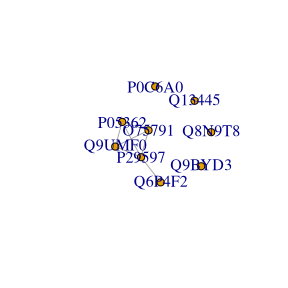

```r
plot(pathway_protein_graph)
```

## Retrieving shared protein-protein interactions

We can complement the information given by pathway ontologies with data of interactions between proteins. For each pair of proteins, we retrieve shared protein-protein interactions, either a direct interaction or an interaction where there’s one mediator protein in the middle (see parameters section).

```r
get_ppi <- function(gene_protein_df, n_intermediate_proteins = 0) {
  endpoint <- "/protein/ppi/pairwise"
  params <- list(
    uniprot_id_list = gene_protein_df %>% pull("uniprot_id") %>% I(),
    n_intermediate_proteins = n_intermediate_proteins
  )
  df <- query_epigraphdb(
    route = endpoint,
    params = params,
    mode = "table",
    method = "POST"
  )

  if (nrow(df) > 0) {
    res_df <- gene_protein_df %>%
      select(protein = uniprot_id) %>%
      left_join(df, by = c("protein"))
  } else {
    res_df <- gene_protein_df %>%
      select(protein = uniprot_id) %>%
      mutate(assoc_protein = NA_character_, path_size = NA_integer_)
  }
  res_df
}
ppi_df <- get_ppi(gene_protein_df, n_intermediate_proteins = PPI_N_INTERMEDIATE_PROTEINS)
ppi_df
```

```
#> # A tibble: 1,686 x 3
#>    protein assoc_protein path_size
#>    <chr>   <chr>             <int>
#>  1 P0C6A0  P0C6A0                2
#>  2 P0C6A0  P0C6A0                2
#>  3 Q6P4F2  Q6P4F2                2
#>  4 Q6P4F2  Q6P4F2                2
#>  5 Q6P4F2  Q6P4F2                2
#>  6 Q6P4F2  Q6P4F2                2
#>  7 Q6P4F2  Q6P4F2                2
#>  8 Q6P4F2  Q6P4F2                2
#>  9 Q6P4F2  Q6P4F2                2
#> 10 Q6P4F2  Q6P4F2                2
#> # … with 1,676 more rows
```

Like in the query for pathway data, we convert and analyse these results as a graph.

```r
get_shared_ppi <- function(ppi_df) {
  per_row <- function(ppi_df, x, y) {
    res <- ppi_df %>%
      filter(
        `protein` == x,
        `assoc_protein` == y
      ) %>%
      nrow() %>%
      `>`(0)
    res
  }

  pairwise_permutations <- ppi_df %>%
    pull(`protein`) %>%
    unique() %>%
    gtools::permutations(n = length(.), r = 2, v = .)
  shared_ppi_df <- tibble(
    protein = pairwise_permutations[, 1],
    assoc_protein = pairwise_permutations[, 2]
  ) %>%
    mutate(
      shared_ppi = map2_lgl(`protein`, `assoc_protein`, function(x, y) {
        per_row(ppi_df = ppi_df, x = x, y = y)
      }),
      combination = map2_chr(`protein`, `assoc_protein`, function(x, y) {
        comb <- sort(c(x, y))
        paste(comb, collapse = ",")
      }),
      connected = shared_ppi
    )

  shared_ppi_df
}

shared_ppi_df <- get_shared_ppi(ppi_df)
n_ppi_pairs <- shared_ppi_df %>%
  filter(shared_ppi) %>%
  nrow()
print(glue::glue("Num. shared_ppi pairs: {n_ppi_pairs}"))
```

```
#> Num. shared_ppi pairs: 10
```

```r
shared_ppi_df
```

```
#> # A tibble: 72 x 5
#>    protein assoc_protein shared_ppi combination   connected
#>    <chr>   <chr>         <lgl>      <chr>         <lgl>
#>  1 O75791  P05362        TRUE       O75791,P05362 TRUE
#>  2 O75791  P0C6A0        FALSE      O75791,P0C6A0 FALSE
#>  3 O75791  P29597        TRUE       O75791,P29597 TRUE
#>  4 O75791  Q13445        FALSE      O75791,Q13445 FALSE
#>  5 O75791  Q6P4F2        FALSE      O75791,Q6P4F2 FALSE
#>  6 O75791  Q8N9T8        FALSE      O75791,Q8N9T8 FALSE
#>  7 O75791  Q9BYD3        FALSE      O75791,Q9BYD3 FALSE
#>  8 O75791  Q9UMF0        FALSE      O75791,Q9UMF0 FALSE
#>  9 P05362  O75791        TRUE       O75791,P05362 TRUE
#> 10 P05362  P0C6A0        FALSE      P05362,P0C6A0 FALSE
#> # … with 62 more rows
```

```r
ppi_protein_graph <- protein_df_to_graph(shared_ppi_df)
ppi_protein_groups <- graph_to_protein_groups(ppi_protein_graph)
ppi_protein_groups %>% str()
```

```
#> tibble [5 × 2] (S3: tbl_df/tbl/data.frame)
#>  $ group_member:List of 5
#>   ..$ 1: chr [1:4] "O75791" "P05362" "P29597" "Q9UMF0"
#>   ..$ 5: chr [1:2] "Q8N9T8" "Q9BYD3"
#>   ..$ 2: chr "P0C6A0"
#>   ..$ 3: chr "Q13445"
#>   ..$ 4: chr "Q6P4F2"
#>   ..- attr(*, "dim")= int 5
#>   ..- attr(*, "dimnames")=List of 1
#>   .. ..$ : chr [1:5] "1" "5" "2" "3" ...
#>  $ group_size  : Named int [1:5] 4 2 1 1 1
#>   ..- attr(*, "names")= chr [1:5] "1" "5" "2" "3" ...
```

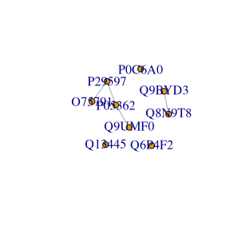

```r
plot(ppi_protein_graph)
```